# Serology of HFMD 2023

**Library**

```r
library(readxl)
library(lubridate)
library(ggplot2)
library(cowplot)
library(tidyverse)
library(hrbrthemes)
library(ggsci)
library(patchwork)
library(plotly)
library(gtsummary)
library(reshape2)
library(ggspatial)
library(serosv)
library(locfit)
Sys.setlocale("LC_TIME", "English")
```

```
[1] "English_United States.1252"
```

**Function**

```r
# function from serosv package

## plot function
plot_util <- function(age, pos, tot, sero, foi){
  plot <- ggplot(data = data.frame(age, pos, tot), aes(x = age, y = pos/tot)) +
    geom_point(size = 8*(pos)/max(tot), shape = 1)+
    labs(y="Seroprevalence", x="Age")+
    coord_cartesian(xlim=c(0,max(age)), ylim=c(0, 1)) +
    scale_y_continuous(
      name = "Seroprevalence",
      sec.axis = sec_axis(~.*1, name = " Force of infection")
    ) + set_plot_style()

  # === Add seroprevalence layer
  if (class(sero) == "data.frame"){
    # --- Sero is dataframe when confidence interval is computed
    plot <- plot + geom_smooth(aes_auto(sero, col = "sero", linetype="sero",
                                        fill = "ci"), data=sero,
                               stat="identity",lwd=0.5)
  }else{
    # --- Simply plot seroprevalence line if CI cannot be computed
    plot <- plot + geom_line(aes(x = age, y = sero, col = "sero", linetype="sero"),
                             stat="identity",lwd=0.5)
  }

  # === Add foi layers
  if (class(foi) == "data.frame"){
    # --- Handle cases like that of weibull model
    plot <- plot + geom_line(aes_auto(foi, col = "foi", linetype="foi"), data=foi,
                             stat="identity",lwd=0.5)
  }else if (length(age) != length(foi)){
    # --- handle some cases when length of age differs from length of foi
    age <- age[c(-1,-length(age))]
    foi <- data.frame(x = age, y = foi)
    plot <- plot + geom_line(aes_auto(foi, col = "foi", linetype="foi"), data = foi,
                             lwd = 0.5)
  }else{
    # --- Simply plot foi
    plot <- plot + geom_line(aes(x = age, y = foi, col = "foi", linetype="foi"),
                             lwd = 0.5)
  }
  plot
}


## compute confident interval function
compute_ci.lp_model <- function(x,ci = 0.95, ...){
  ages <- x$df$age
  crit<- crit(x$pi,cov = ci)$crit.val
  mod1 <- predict(x$pi, data.frame(a = ages),se.fit = TRUE)
  out.DF <- data.frame(x = ages, y = mod1$fit,ymin= mod1$fit-crit*(mod1$se.fit/100),
                       ymax= mod1$fit+crit*(mod1$se.fit/100))
  out.DF
}

## plot local polynomial model
plot_lp_model <- function(x, ...) {
  out.DF <- compute_ci.lp_model(x)

  with(x$df, {
    plot_util(age = age, pos = pos, tot = tot, sero = out.DF, foi = x$foi)
  })
}

## function to aggregate line listing data
aggregate2  <- function(data){

  data$age2 = as.factor(cut(data$age+0.0000000001, c(0:15), right=TRUE ))
  levels(data$age2) = seq(0.5,14.5,by =1)

  agr_out <- data %>% group_by(age2) %>%
    count(pos) %>%  pivot_wider(names_from = pos, values_from = n) %>%
    replace(is.na(.), 0) %>% as.data.frame() %>%
    mutate(sp = `1`/(`1`+`0`))
  colnames(agr_out) <- c("age","neg","pos","sp")
  return(agr_out)
}
```

**Data**

```r
apr_2023 <- read_excel("D:/OUCRU/hfmd/data/4_2023.xlsx")
aug_2023 <- read_excel("D:/OUCRU/hfmd/data/08_2023.xlsx")
dec_2022 <- read_excel("D:/OUCRU/hfmd/data/12_2022.xls")
dec_2023 <- read_excel("D:/OUCRU/hfmd/data/12_2023.xlsx")

t423 <- data.frame(apr_2023[-c(1,2),10:14])
t423$pos <- replace(t423$...14,is.na(t423$...14),0) %>%
  str_detect(regex(paste(2^(4:10), collapse = "|"))) %>%
  as.integer(as.logical())
colnames(t423) <- c("age","col_day","col_month","col_year","neutralization","pos")
t423$age <- as.numeric(t423$age)

t823 <- data.frame(aug_2023[-c(1,2),c(9,14:17)])
t823$pos <- str_detect(t823$...17,regex(paste(2^(4:10), collapse = "|"))) %>%
  as.integer(as.logical())
colnames(t823) <- c("age","col_day","col_month","col_year","neutralization","pos")
t823$age <- as.numeric(t823$age)

t1222 <- data.frame(dec_2022[-c(1,2),10:14])
t1222$pos <- replace(t1222$...14,is.na(t1222$...14),0) %>%
  str_detect(regex(paste(2^(4:10), collapse = "|"))) %>%
  as.integer(as.logical())
colnames(t1222) <- c("age","col_day","col_month","col_year","neutralization","pos")
t1222$age <- as.numeric(t1222$age)

t1223 <- data.frame(dec_2023[-c(1,2),c(9,14:17)])
t1223$pos <- replace(t1223$...17,is.na(t1223$...17),0) %>%
  str_detect(regex(paste(2^(4:10), collapse = "|"))) %>%
  as.integer(as.logical())
colnames(t1223) <- c("age","col_day","col_month","col_year","neutralization","pos")
t1223$age <- as.numeric(t1223$age)
```

```r
head(t1223)
```

```
        age col_day col_month col_year neutralization pos
1 0.6520548       6        12     2023           <1:8   0
2 0.8246575       7        12     2023           <1:8   0
3 0.1232877       6        12     2023           <1:8   0
4 0.9808219       6        12     2023           <1:8   0
5 0.5698630       6        12     2023           <1:8   0
6 1.7780822       6        12     2023           <1:8   0
```

# Fitting seroprevalence and calculate force of infection

In this step, I used a non-parametric approach - a local polynomial in Niel Hens 2012 book to fit seroprevalence from serology data (Hens et al. 2012)

Within the local polynomial framework, the linear predictor $\eta(a)$ is approximated locally, at one particular value $a_0$ for age, by a line (local linear, degree $p$ = 1), or a parabola (local quadratic, degree $p$ = 2). The appropriate degree p is a first choice to be made. For a general degree, it holds that the (Taylor) approximation

$$\eta(a_i) \approx \eta(a_0) + \eta^{(1)} (a_0)(a_i - a_0) + \frac{\eta^{(2)}(a_0)}{2} (a_i - a_0)^2 + ... + \frac{\eta^{(p)}(a_0)}{p!} (a_i-a_0)^p$$

is quite accurate, under the condition that $a_i$ is close enough to $a_0$, and that the curve $\eta(\cdot)$ is sufficiently smooth at the age $a_0$ (smoothness is mathematically translated into the existence of the derivatives $\eta^{(1)} (a_0),...,\eta^{(p)} (a_0)$). This mathematical fact naturally inspires the idea to fit a polynomial locally, only for observations with $a_i$ close to $a_0$. This “closeness” is governed by the so-called kernel function $K_h$, assigning high weights to data points with age values close to $a_0$ and low or zero weights to data points further or far away. The kernel function $K_h$ is typically a density function (such as the bell-shaped gaussian density), having mean 0 and variance $h$. This variance parameter $h$ is the so-called smoothing parameter.

Three popular kernels: the Gaussian kernel, the tricube kernel $(70/81×(1−(|u|)3)3 (|u| ≤ 1))$, and the Epanechnikov kernel $(3/4×(1−u2)(|u| ≤ 1))$.

Force of infection

$$\lambda (a) = \eta'(a) \pi(a)$$

Local polynomial approach is based on the maximization of

$$\sum_{i=1}^{N} l_i \{Y_i,g^{-1} (\beta_0 + \beta_1 (a_i - a_0)+ \beta_2 (a_i - a_0)^2 + ... + \beta_p (a_i - a_0)^p)\} K_h(a_i - a_0),$$

where

$$l_i \{Y_i,\pi\} = Y_i log\{\pi\} + (1 - Y_i) log\{1 - \pi\}$$

Function `lp_model` from `serosv` package was used for this approach. Parameter `nn` refers to the proportion of closest neighbors, E.g. `nn` = 0.7 a refers to local fit only incorporating 70% of the data, namely the 70% closest neighbors, when fitting the curve at a particular age $a_0$. Parameter `h` refers to local constant bandwidths.

**Local polynomial function**

```r
lp_model <- function(age, pos, tot, kern="tcub", nn=0, h=0, deg=2) {
  if (missing(nn) & missing(h)) {
    nn <- 0.7 # default nn from lp()
  }

  model <- list()

  y <- pos/tot
  estimator <- lp(age, deg=deg, nn=nn, h=h)
  model$pi  <- locfit(y~estimator, family="binomial", kern=kern)
  model$eta <- locfit(y~estimator, family="binomial", kern=kern, deriv=1)
  model$sp  <- fitted(model$pi)
  model$foi <- fitted(model$eta)*fitted(model$pi) # λ(a)=η′(a)π(a)
  model$df  <- list(age=age, pos=pos, tot=tot)

  class(model) <- "lp_model"
  model
}
```

Choosing value of `nn` and/or `h` based on cross-validation and the generalized cross-validation (GCV) method. The cross-validation bandwidth minimizes the cross-validation criterion.

$$CV(h) = \sum_{i=1}^{N} l_i \{Y_i, \widehat{\pi_{i}}^{h} (a_i)\}$$

where $\widehat{\pi_{i}}^{h} (a_i)$ is defined as the local estimator at ai leaving out the ith observation and using bandwidth $h$. The CV-criterion is minimized as a function of $h$ for a constant bandwidth or as a function of the percentage of neighbors α for a nearest neighbor bandwidth.

**plot_gcv function**

```r
plot_gcv <- function(age, pos, tot, nn_seq, h_seq, kern="tcub", deg=2) {
  y <- pos/tot

  # --- Plot for nn seq
  res <-  cbind(nn_seq, summary(gcvplot(y~age, family="binomial", alpha=nn_seq)))
  nn_plot <- ggplot() +
    geom_line(aes(x = res[,1], y = res[,3]), col = "royalblue") +
    labs(x="nn (% Neighbors)", y="GCV")


  # --- Plot for h seq
  h_seq_ <- cbind(rep(0, length(h_seq)), h_seq)
  h_res <- cbind(h_seq_[,2],summary(gcvplot(y~age,family="binomial",alpha=h_seq_)))
  h_plot <- ggplot() +
    geom_line(aes(x = h_res[,1], y = h_res[,3]), col = "royalblue") +
    labs(x="h (Bandwidth)", y="GCV")

  # --- Combine 2 plots
  nn_plot + h_plot + plot_layout(ncol=2)
}
```

## December 2022

**Data**

```r
a1222 <- aggregate2(t1222)
a1222
```

```
    age neg pos  sp
1   0.5   5   0 0.0
2   1.5   4   1 0.2
3   2.5   5   0 0.0
4   3.5   5   0 0.0
5   4.5   4   1 0.2
6   5.5   3   2 0.4
7   6.5   5   0 0.0
8   7.5   1   4 0.8
9   8.5   2   3 0.6
10  9.5   4   1 0.2
11 10.5   1   4 0.8
12 11.5   3   2 0.4
13 12.5   3   2 0.4
14 13.5   1   4 0.8
15 14.5   2   3 0.6
```

**GCV**

```r
plot_gcv(
  age = a1222$age,
  pos = a1222$pos,
  tot = a1222$pos+ a1222$neg,
  nn_seq = seq(0.2, 0.8, by=0.1),
  h_seq = seq(5, 25, by=1)
)
```

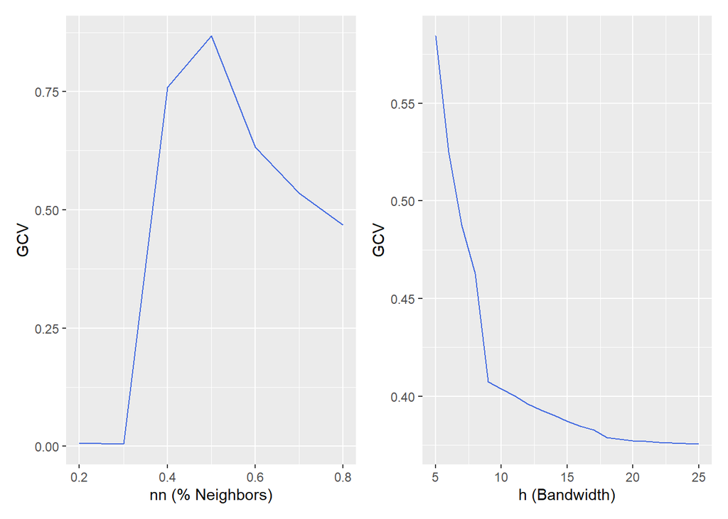

```r
lp_fit1222 <- lp_model(age = as.numeric(as.character(a1222$age)),
                       pos = a1222$pos,
                       tot = a1222$pos + a1222$neg,
                       kern="tcub", nn = 0.3,h=25, deg=3)

plot1222 <- plot_lp_model(lp_fit1222)+
  set_plot_style(
    sero = "#0808cf",
    ci = "#0808cf"
  )+
  theme_classic() +
  scale_x_continuous(breaks = seq(0,15,by=1))+
  theme(legend.position="none")+
  annotate("text", x = 2, y = 0.85, label = c("Dec 2022"),size = 4)
```

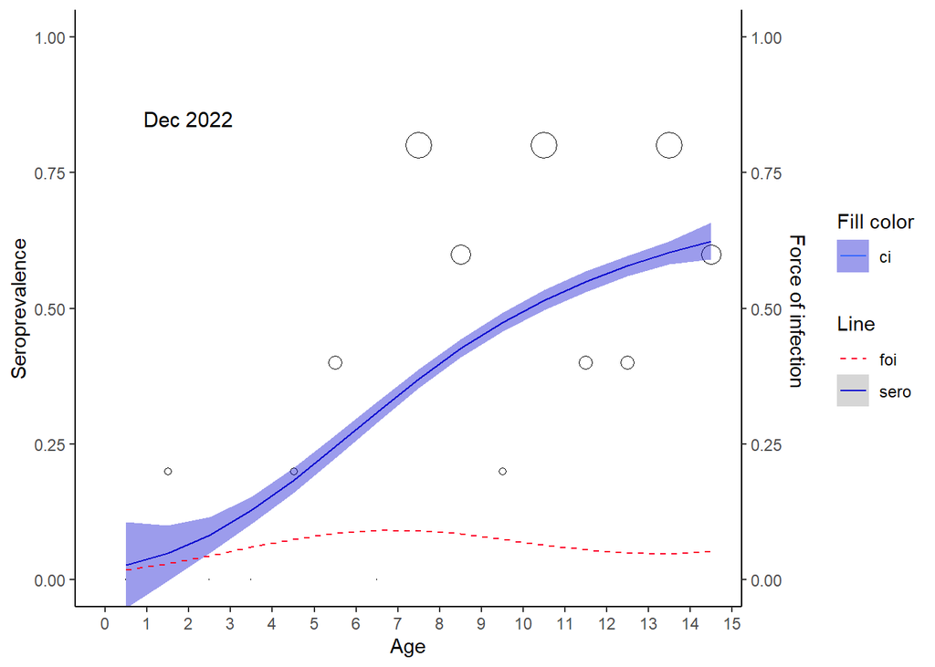

## April 2023

**Data**

```r
a423 <- aggregate2(t423)
a423
```

```
    age neg pos  sp
1   0.5   4   1 0.2
2   1.5   5   0 0.0
3   2.5   5   0 0.0
4   3.5   4   1 0.2
5   4.5   3   2 0.4
6   5.5   4   1 0.2
7   6.5   4   1 0.2
8   7.5   0   5 1.0
9   8.5   2   3 0.6
10  9.5   3   2 0.4
11 10.5   0   5 1.0
12 11.5   2   3 0.6
13 12.5   2   3 0.6
14 13.5   4   1 0.2
15 14.5   2   3 0.6
```

**GCV**

```r
plot_gcv(
  age = a423$age,
  pos = a423$pos,
  tot = a423$pos+ a423$neg,
  nn_seq = seq(0.2, 0.8, by=0.1),
  h_seq = seq(5, 25, by=1)
)
```

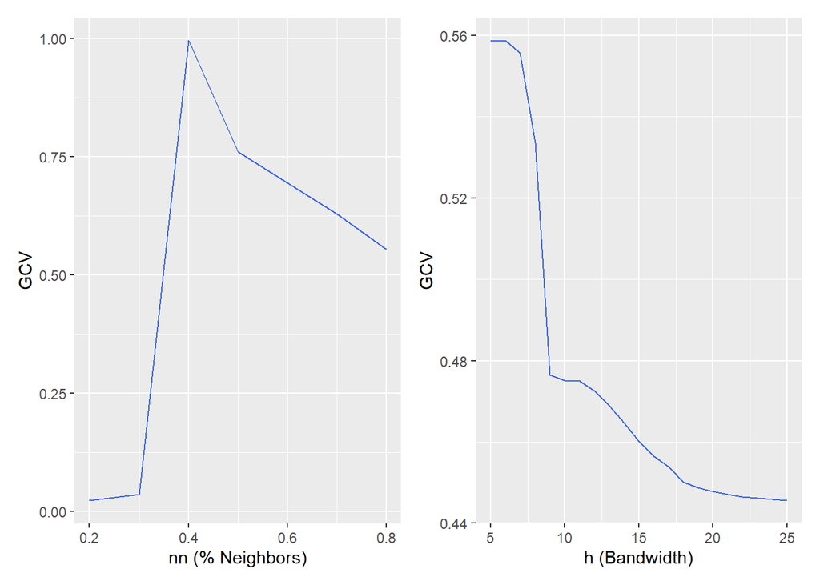

```r
lp_fit423 <- lp_model(age = as.numeric(as.character(a423$age)),
                      pos = a423$pos,
                      tot = a423$pos+ a423$neg,
                      kern="tcub", nn = 0.7, h = 25, deg=3)

plot423 <- plot_lp_model(lp_fit423)+
  set_plot_style(
    sero = "#ed097b",
    ci = "#ed097b"
  )+
  theme_classic() +
  scale_x_continuous(breaks = seq(0,15,by=1))+
  theme(legend.position="none")+
  annotate("text", x = 2, y = 0.85, label = c("Apr 2023"),size = 4)
```

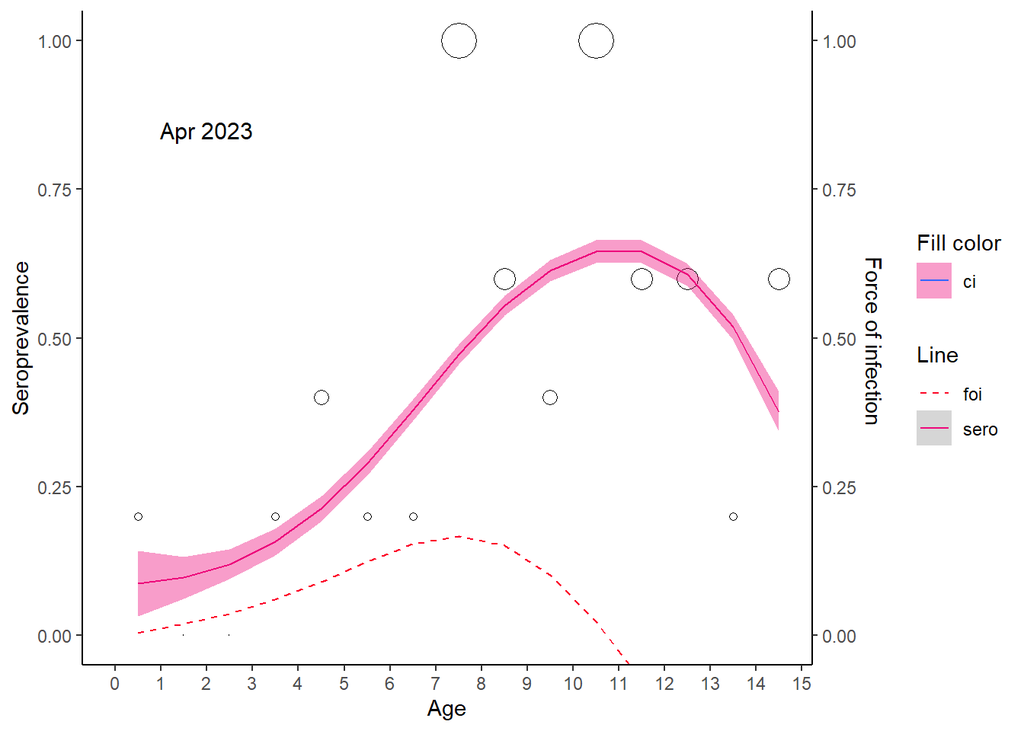

## August 2023

**Data**

```r
a823 <- aggregate2(t823)
a823
```

```
    age neg pos  sp
1   0.5   5   0 0.0
2   1.5   0   5 1.0
3   2.5   4   1 0.2
4   3.5   2   3 0.6
5   4.5   0   5 1.0
6   5.5   4   1 0.2
7   6.5   4   1 0.2
8   7.5   3   2 0.4
9   8.5   0   5 1.0
10  9.5   5   0 0.0
11 10.5   1   4 0.8
12 11.5   3   2 0.4
13 12.5   3   2 0.4
14 13.5   3   2 0.4
15 14.5   2   3 0.6
```

**GCV**

```r
plot_gcv(
  age = a823$age,
  pos = a823$pos,
  tot = a823$pos+ a823$neg,
  nn_seq = seq(0.2, 0.8, by=0.1),
  h_seq = seq(5, 100, by=1)
)
```

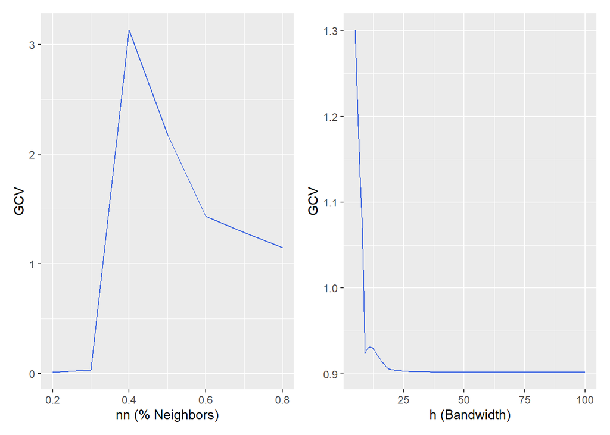

```r
lp_fit823 <- lp_model(age = as.numeric(as.character(a823$age)),
                      pos = a823$pos,
                      tot = a823$pos+ a823$neg,
                      kern="tcub", nn = 0.3, h=25, deg=3)

plot823 <-plot_lp_model(lp_fit823)+
  set_plot_style(
    sero = "#ed6b00",
    ci = "#ed6b00"
  )+
  theme_classic() +
  scale_x_continuous(breaks = seq(0,15,by=1))+
  theme(legend.position="none")+
  annotate("text", x = 2, y = 0.85, label = c("Aug 2023"),size = 4)
```

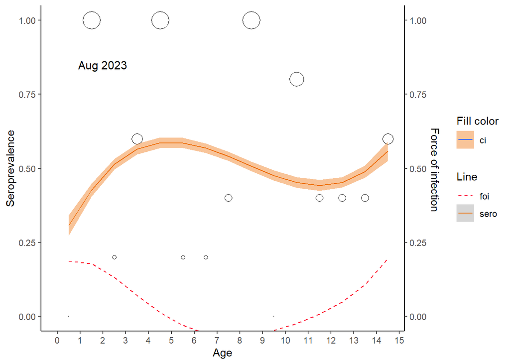

## Dec 2023

**Data**

```r
a1223 <- aggregate2(t1223)
a1223
```

```
    age neg pos  sp
1   0.5   5   0 0.0
2   1.5   5   0 0.0
3   2.5   3   2 0.4
4   3.5   4   1 0.2
5   4.5   2   3 0.6
6   5.5   3   2 0.4
7   6.5   2   3 0.6
8   7.5   2   3 0.6
9   8.5   2   3 0.6
10  9.5   2   3 0.6
11 10.5   4   1 0.2
12 11.5   3   2 0.4
13 12.5   4   1 0.2
14 13.5   3   2 0.4
15 14.5   2   3 0.6
```

**GCV**

```r
plot_gcv(
  age = a1223$age,
  pos = a1223$pos,
  tot = a1223$pos+ a1223$neg,
  nn_seq = seq(0.2, 0.8, by=0.1),
  h_seq = seq(5, 25, by=1)
)
```

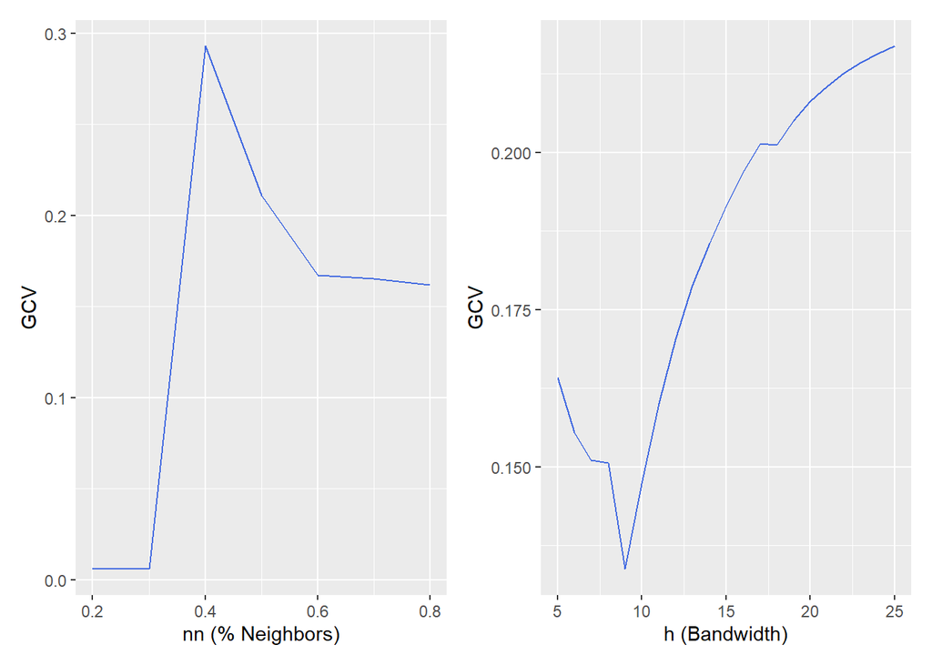

```r
lp_fit1223 <- lp_model(age = as.numeric(as.character(a1223$age)),
                      pos = a1223$pos,
                      tot = a1223$pos+ a1223$neg,
                      kern="tcub", nn =.8,h=9, deg=2)
plot1223 <-plot_lp_model(lp_fit1223)+
  set_plot_style(
    sero = "#33516b",
    ci = "#33516b"
  )+
  theme_classic()+
  scale_x_continuous(breaks = seq(0,15,by=1))+
  # theme(legend.position="none")+
  annotate("text", x = 2, y = 0.85, label = c("Dec 2023"),size = 4)
```

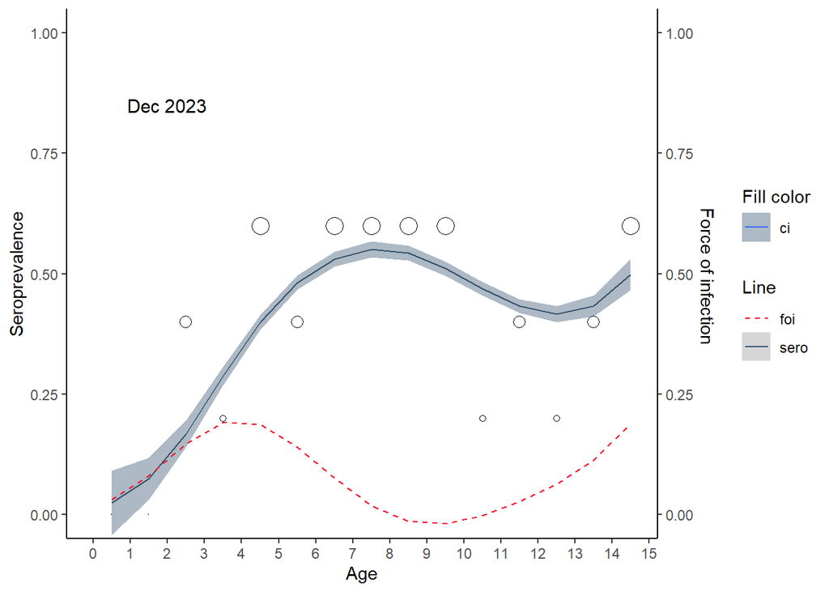

# Combine cases notification and serology data

**Function to calculate seroprevalence by age group (hfmd_sp)**

```r
hfmd_sp <- function(srt){

op <- data.frame()
tg <- list()
model <- list()

for (i in 1:length(srt)) {
  dtaxl <- srt[[i]]

  dtaxl$col_date<- str_c(dtaxl$col_year,dtaxl$col_month,dtaxl$col_day,sep = " ") %>% ymd()
  ##agegr_cut <- c(0, 3, 5, 10, 15, Inf)
  agegr_cut <- c(0, 5, 10, 15, Inf)
  ##dtaxl$agegr <- cut(as.numeric(dtaxl$age), breaks = c(0, 3, 5, 10, 15, Inf), right = F)
  dtaxl$agegr <- cut(as.numeric(dtaxl$age), breaks = c(0, 5, 10, 15, Inf), right = F)
  ##dtaxl$agegr <- factor(dtaxl$agegr, labels = c("0-3", "3-5", "5-10", "10-15"))
  dtaxl$agegr <- factor(dtaxl$agegr, labels = c("0-5", "5-10", "10-15"))
  dtaxl$pos <- as.integer(as.logical(dtaxl$pos))

  arg_date <- data.frame(table(dtaxl$col_date))

  outcomt <- data.frame(
    min = as.Date(arg_date$Var1[1]),
    max = as.Date(arg_date$Var1[nrow(arg_date)]),
    mid = as.Date(arg_date$Var1[ceiling(nrow(arg_date)/2)])
    )

  dtaxl$mid_date <- rep(outcomt$mid,nrow(dtaxl))

  fn_out <- dtaxl  %>%
    group_by(mid_date,agegr)  %>%
    count(pos)  %>%  pivot_wider(names_from = pos, values_from = n) %>%
    data.frame() %>%
    magrittr::set_colnames(c("col_date", "age_gr", "neg","pos")) %>%
    replace(is.na(.), 0) %>%
    dplyr::mutate(tot = neg + pos,
                pre = pos / tot *100)

  op  <- rbind(op,fn_out)
  tg[[i]] <- outcomt
 }

model$sp <- op
model$time <- tg
return(model)
}
```

```r
mm <- hfmd_sp(list(t423,t823,t1222,t1223))

for (i in 1:12) {
  mm$sp$lwr[i] <- prop.test(mm$sp$pos[i],mm$sp$tot[i],correct=TRUE)$conf.int[1]*100
  mm$sp$upr[i] <- prop.test(mm$sp$pos[i],mm$sp$tot[i],correct=TRUE)$conf.int[2]*100
}

mm$sp$col_date <- mm$sp$col_date %>% str_replace_all(
  c( "2023-04-15"  = "2023-04-13",
     "2023-08-15"  = "2023-08-17",
     "2023-12-10"  = "2023-12-14",
     "2022-12-20"  = "2022-12-22"
  ))
```

```r
ts <- ggplot(data = mm$sp)+
  geom_bar(data = df_plot, aes(x = as.Date(adm_week), y = n),stat = "identity",
           alpha = 0.5) +
  geom_line(aes(x = as.Date(col_date),y = pre*20,
                colour = age_gr
  ))+
  geom_ribbon(aes(x = as.Date(col_date),y = pre*20,
                  ymin=lwr*20, ymax=upr*20,
                  fill = factor(age_gr)), alpha=.3, linetype=0)+
  scale_y_continuous(name = "Number of cases",
                     sec.axis = sec_axis(~./20,
                                         name = "Seroprevalence by age group"))+
  labs(x = "Date", color = NULL, fill = NULL)+
  theme_classic()
```

```r
ts2 <- ts +
  geom_vline(xintercept = as.Date("2022-12-01"),
             alpha = 0.4,col = "#0808cf")+
  geom_vline(xintercept = as.Date("2022-12-30"),
             alpha = 0.4,col = "#0808cf")+
  geom_vline(xintercept = as.Date("2023-04-01"),
             alpha = 0.4,col = "#ed097b")+
  geom_vline(xintercept = as.Date("2023-04-30"),
             alpha = 0.4,col = "#ed097b")+
  geom_vline(xintercept = as.Date("2023-08-01"),
             alpha = 0.4,col = "#ed6b00")+
  geom_vline(xintercept = as.Date("2023-08-30"),
             alpha = 0.4,col = "#ed6b00")+
  geom_vline(xintercept = as.Date("2023-12-01"),
             alpha = 0.4,col = "#33516b")+
  geom_vline(xintercept = as.Date("2023-12-30"),
             alpha = 0.4,col = "#33516b")+
  xlim(as.Date("2022-11-24"),as.Date("2024-01-01"))
```

```r
result_sero2 <- plot1222 | plot423 | plot823 | plot1223

result_sero2/
  ts2
```

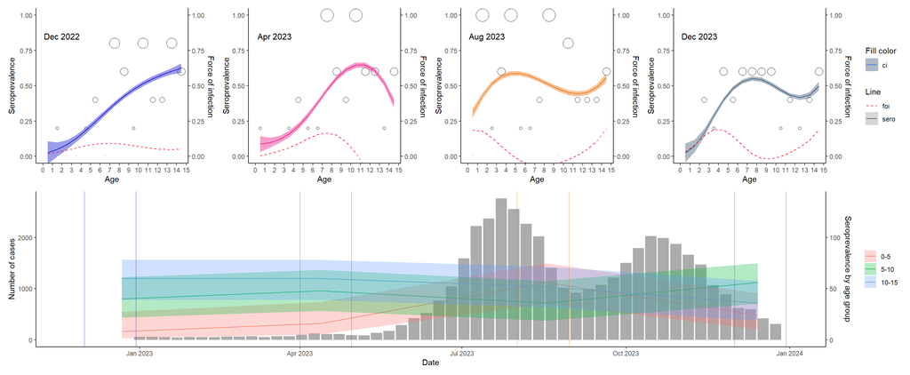

# Who Acquires Infection from Whom? The Traditional Approach

If mean duration of infectiousness D is short compared to the timescale on which transmission and mortality rate vary, the force of infection (FOI) $\lambda(a)$ can be approximated by (Anderson and May 1991)

$$\lambda(a) = D \intop_{0}^{\infty} \beta(a,a') \lambda(a') S(a') da',$$

where $\beta(a,a')$ denotes the transmission rate, i.e., the per capita rate at which an individual of age $a'$ makes an effective contact with a person of age $a$ per year, and $S(a')$ denotes the number of susceptible persons of age $a'$. Assuming a closed population of size N and that we are in demographic and endemic equilibrium. Without loss of generality, assumed a prompt loss of maternal immunity at age A:

$$m(a) = exp(-\intop_{0}^{a} \gamma(u)du) = \begin{equation}\begin{cases} 1, & \text{if $a \leq A$} \\0, & \text{if $a > A$} \end{cases}\end{equation}$$

meaning that all newborns are protected by maternal antibodies until a certain age A after which they instantaneously move to the susceptible class. We will refer to this assumption as the Type I maternal antibody assumption. Under this assumption, the proportion of susceptibles becomes

$$s(a) = exp(-\intop_{A}^{a} \lambda(u) du), \text{if $a > A$}$$

where $\lambda(a)$ denotes the age-specific FOI, and $s(a) = 0$ if $a \leq A$

Considering a large population of fixed size N with age-specific mortality rate $\mu(a)$ and with age density

$$L^{-1} exp\{-\intop_{0}^{a} \mu(u) du\}$$

Where $L$ is the life expectancy, $S(a')$ can be rewritten as $S(a') = N/L.s(a').m(a')$, where $s(a')$ and $m(a') = exp\{-\intop_{0}^{a}\mu(u) du\}$, denote the proportion susceptible and the survival function at age $a'$, respectively.

Given the assumption of instantaneous loss of maternal immunity at age A, rewrite the age-specific FOI

$$\lambda(a) = \frac{ND}{L} \intop_{A}^{\infty} \beta(a,a')\lambda(a')s(a')m(a')da', \text{for $a \geq A$}$$

## The Discretized Mass Action Principle

Assumming a constant FOI in each age class, denote the first age interval ($a_{[1]},a_{[2]}$) and the $j$th age interval $[a_{[j]},a_{[j+1]}$), j = 2,…,J, where $a_{[1]} = A$ and $a_{[J + 1]} = L$. The prevalence of immune individuals of age a in the jth age interval is now well approximated by

$$\pi(a) = 1 - exp(- \sum^{j-1}_{k=1} \lambda_k (a_{[k+1]} - a_{[k]}) - \lambda_j(a-a_{[j]}))$$

Note that the prevalence of immune individuals is allowed to vary continuously with age and that we do not summarize the binary seroprevalence outcomes into a proportion per age class. Further, the FOI for age class i equals (i = 1,…,J):

$$\lambda_i = \frac{ND}{L} \sum_{j=1}^{J} \beta_{ij} \frac{\lambda_i}{\lambda_j + \mu_j} [exp(-\sum_{k=1}^{j-1}(\lambda_k + \mu_k)(a_{[k+1]}-a_{[k]}))- exp(-\sum_{k=1}^{j}(\lambda_k + \mu_k)(a_{[k+1]}-a_{[k]}))] (14.10)$$

where D denotes the mean duration of infectiousness and $\beta_{ij}$ the per capita rate at which an individual of age class j makes an effective contact with a person of age class i, per year. The transmission rates $\beta_{ij}$ make up a $J × J$ matrix, the so-called WAIFW matrix

Specific structures, often used in literature, are homogeneous mixing, proportional mixing, separable mixing

$$W1 = \begin{pmatrix}\beta_1&\beta_6&\beta_6&\beta_6&\beta_6&\beta_6\\\beta_6&\beta_2&\beta_6&\beta_6&\beta_6&\beta_6\\\beta_6&\beta_6&\beta_3&\beta_6&\beta_6&\beta_6\\\beta_6&\beta_6&\beta_6&\beta_4&\beta_6&\beta_6\\\beta_6&\beta_6&\beta_6&\beta_6&\beta_5&\beta_6\\\beta_6&\beta_6&\beta_6&\beta_6&\beta_6&\beta_6\end{pmatrix}$$
$$W3 = \begin{pmatrix}\beta_1&\beta_1&\beta_1&\beta_4&\beta_5&\beta_6\\\beta_1&\beta_2&\beta_3&\beta_4&\beta_5&\beta_6\\\beta_1&\beta_3&\beta_3&\beta_4&\beta_5&\beta_6\\\beta_4&\beta_4&\beta_4&\beta_4&\beta_5&\beta_6\\\beta_5&\beta_5&\beta_5&\beta_5&\beta_5&\beta_6\\\beta_6&\beta_6&\beta_6&\beta_6&\beta_6&\beta_6\end{pmatrix}$$

$$W5 = \begin{pmatrix}\beta_1&\beta_6&\beta_6&\beta_6&\beta_6&\beta_6\\\beta_6&\beta_2&\beta_6&\beta_6&\beta_6&\beta_6\\\beta_6&\beta_6&\beta_3&\beta_6&\beta_6&\beta_6\\\beta_6&\beta_6&\beta_6&\beta_4&\beta_6&\beta_6\\\beta_6&\beta_6&\beta_6&\beta_6&\beta_5&\beta_6\\\beta_6&\beta_6&\beta_6&\beta_6&\beta_6&\beta_5\end{pmatrix}$$

$$W2 = \begin{pmatrix}\beta_1&\beta_1&\beta_3&\beta_4&\beta_5&\beta_6\\\beta_1&\beta_2&\beta_3&\beta_4&\beta_5&\beta_6\\\beta_3&\beta_3&\beta_3&\beta_4&\beta_5&\beta_6\\\beta_4&\beta_4&\beta_4&\beta_4&\beta_5&\beta_6\\\beta_5&\beta_5&\beta_5&\beta_5&\beta_5&\beta_6\\\beta_6&\beta_6&\beta_6&\beta_6&\beta_6&\beta_6\end{pmatrix}$$

$$W4 = \begin{pmatrix}\beta_1&\beta_1&\beta_1&\beta_1&\beta_1&\beta_1\\\beta_2&\beta_2&\beta_2&\beta_2&\beta_2&\beta_2\\\beta_3&\beta_3&\beta_3&\beta_3&\beta_3&\beta_3\\\beta_4&\beta_4&\beta_4&\beta_4&\beta_4&\beta_4\\\beta_5&\beta_5&\beta_5&\beta_5&\beta_5&\beta_5\\\beta_6&\beta_6&\beta_6&\beta_6&\beta_6&\beta_6\end{pmatrix}$$

$$W6 = \begin{pmatrix}\beta_1&0&0&0&0&0&\\0&\beta_2&0&0&0&0&\\0&0&\beta_3&0&0&0&\\0&0&0&\beta_4&0&0&\\0&0&0&0&\beta_5&0&\\0&0&0&0&0&\beta_6\end{pmatrix}$$

**What happen in the code**

In order to estimate the transmission parameters $\beta = (\beta_1,...,\beta_6)^T$from seroprevalence data, book author follow (Anderson and May 1991). Since (14.10) constitutes a system of six equations and six unknowns, there exists a unique matrix $D(\lambda)$ such that (14.10) can be rewritten as $\lambda = D(\lambda) \beta$. Conditional on $D(\lambda)$ being invertible, the parameter vector $\beta$ can be estimated by fitting a piecewise constant FOI (in my cases used local polynomial) to the seroprevalence data and using $\widehat{\beta} = D(\widehat{\lambda})^{-1} \widehat{\lambda}$ . Whenever $\widehat{\beta} = D(\widehat{\lambda})^{-1} \widehat{\lambda} \geq 0$, one says that W has a **regular configuration** for the data.

As an example, we now derive $D(\lambda)$ for W3. Denote

$$\Psi_i = \frac{ND}{L} \frac{\lambda_i}{\lambda_j + \mu_j} [exp(-\sum_{k=1}^{j-1}(\lambda_k + \mu_k)(a_{[k+1]}-a_{[k]}))- exp(-\sum_{k=1}^{j}(\lambda_k + \mu_k)(a_{[k+1]}-a_{[k]}))]$$

for $j = 1,...,J$, then $\lambda = D(\lambda) \beta$ can be rewritten as $\lambda = W \psi^T$. More specifically, given W3, $D(\lambda)$ looks like

$$\begin{pmatrix}\sum_{j=1}^{3}\psi_j&0&0&\psi_4&\psi_5&\psi_6&\\\psi_1&\psi_2&\psi_3&\psi_4&\psi_5&\psi_6&\\\psi_1&0&\psi_2+\psi_3&\psi_4&\psi_5&\psi_6&\\0&0&0&\sum_{j=1}^{4}\psi_j&\psi_5&\psi_6&\\0&0&0&0&\sum_{j=1}^{5}\psi_j&\psi_6&\\0&0&0&0&0&\sum_{j=1}^{6}\psi_j\end{pmatrix}$$
Similarly, $D(\lambda)$ can be derived for the other WAIFW structures.

# WAIFW matrix for HFMD serology data

**Function for waifw matrix**

```r
waifw.6parms<-function(foihat=foihat,muhat=muhat,breaks=breakpoints,
                       N=N,D=D,Lmax=Lmax){

L <- Lmax*mean(exp(-cumsum(muhat*(floor(breaks)[-1]-
                                  floor(breaks)[-length(breaks)]))))

phi <- cumsum((foihat+muhat)*(breaks[-1]-breaks[-7]))
psi <- N*D/L*foihat/(foihat+muhat)*(exp(-c(0,phi[-6]))-exp(-phi))
psi[foihat+muhat==0]<-N*D/L*(exp(-c(0,phi[-6]))-exp(-phi))[foihat+muhat==0]

My<-My[0:6]

## W1
message1<-c("Regular Configuration")
beta<-rep(NA,6);R0vec<-NA;bij<-NA
Dij<-t(matrix(c(
  psi[1],0,0,0,0,sum(psi[-1]),
  0,psi[2],0,0,0,sum(psi[-2]),
  0,0,psi[3],0,0,sum(psi[-3]),
  0,0,0,psi[4],0,sum(psi[-4]),
  0,0,0,0,psi[5],sum(psi[-5]),
  0,0,0,0,0,sum(psi[1:6])),ncol=6))
if(det(Dij)!=0){
  beta<-solve(Dij,foihat)
  if(sum(beta<0)>0){message1<-c("D(lambda)lambda is irregular")}
  if(sum(beta<0)==0){
    bij<-matrix(beta[6],nrow=6,ncol=6)
    bij[1:breaks[2],1:breaks[2]]<-beta[1]
    bij[(breaks[2]+1):breaks[3],(breaks[2]+1):breaks[3]]<-beta[2]
    bij[(breaks[3]+1):breaks[4],(breaks[3]+1):breaks[4]]<-beta[3]
    bij[(breaks[4]+1):breaks[5],(breaks[4]+1):breaks[5]]<-beta[4]
    bij[(breaks[5]+1):breaks[6],(breaks[5]+1):breaks[6]]<-beta[5]
    bij[(breaks[6]+1):breaks[7],(breaks[6]+1):breaks[7]]<-beta[6]
    R0ij<-(N/L)*D*bij[1:6,1:6]
    Mij<-diag(c(My))
    R0vec<-as.double(eigen(Mij%*%R0ij,symmetric=FALSE,only.values=TRUE,EISPACK=FALSE)$values)
  }}
if (det(Dij)==0){message1<-c("D(lambda) is not invertible")}
beta1<-beta;R0vec1<-R0vec;bij1<-bij

## w2
message2<-c("Regular Configuration")
beta<-rep(NA,6);R0vec<-NA;bij<-NA
Dij<-t(matrix(c(
  sum(psi[1:2]),0,psi[3],psi[4],psi[5],psi[6],
  psi[1],psi[2],psi[3],psi[4],psi[5],psi[6],
  0,0,sum(psi[1:3]),psi[4],psi[5],psi[6],
  0,0,0,sum(psi[1:4]),psi[5],psi[6],
  0,0,0,0,sum(psi[1:5]),psi[6],
  0,0,0,0,0,sum(psi[1:6])),ncol=6))
if(det(Dij)!=0){
  beta<-solve(Dij,foihat)
  if(sum(beta<0)>0){message2<-c("D(lambda)lambda is irregular")}
  if(sum(beta<0)==0){
    bij<-matrix(NA,ncol=6,nrow=6)
    bij[1:breaks[3],1:breaks[2]]<-beta[1]
    bij[1:breaks[2],(breaks[2]+1):breaks[3]]<-beta[1]
    bij[(breaks[2]+1):breaks[3],(breaks[2]+1):breaks[3]]<-beta[2]
    bij[1:breaks[4],(breaks[3]+1):breaks[4]]<-beta[3]
    bij[(breaks[3]+1):breaks[4],1:breaks[4]]<-beta[3]
    bij[1:breaks[5],(breaks[4]+1):breaks[5]]<-beta[4]
    bij[(breaks[4]+1):breaks[5],1:breaks[5]]<-beta[4]
    bij[1:breaks[6],(breaks[5]+1):breaks[6]]<-beta[5]
    bij[(breaks[5]+1):breaks[6],1:breaks[6]]<-beta[5]
    bij[1:breaks[7],(breaks[6]+1):breaks[7]]<-beta[6]
    bij[(breaks[6]+1):breaks[7],1:breaks[7]]<-beta[6]
    R0ij<-(N/L)*D*bij[1:6,1:6]
    Mij<-diag(c(My))
    R0vec<-as.double(eigen(Mij%*%R0ij,symmetric=FALSE,only.values=TRUE,EISPACK=FALSE)$values)
  }}
if (det(Dij)==0){message2<-c("D(lambda) is not invertible")}
beta2<-beta;R0vec2<-R0vec;bij2<-bij

## w3
beta<-rep(NA,6);R0vec<-NA;bij<-NA
Dij<-t(matrix(c(
  sum(psi[1:3]),0,0,psi[4],psi[5],psi[6],
  psi[1],psi[2],psi[3],psi[4],psi[5],psi[6],
  psi[1],0,sum(psi[2:3]),psi[4],psi[5],psi[6],
  0,0,0,sum(psi[1:4]),psi[5],psi[6],
  0,0,0,0,sum(psi[1:5]),psi[6],
  0,0,0,0,0,sum(psi[1:6])),ncol=6))

if(det(Dij)!=0){
  beta<-solve(Dij,foihat)
  if(sum(beta<0)>0){message3<-c("D(lambda)lambda is irregular")}
  if(sum(beta<0)==0){
    bij<-matrix(NA,ncol=6,nrow=6)
    bij[1:breaks[4],1:breaks[2]]<-beta[1]
    bij[1:breaks[2],1:breaks[4]]<-beta[1]
    bij[(breaks[2]+1):breaks[3],(breaks[2]+1):breaks[3]]<-beta[2]
    bij[(breaks[2]+1):breaks[4],(breaks[3]+1):breaks[4]]<-beta[3]
    bij[(breaks[3]+1):breaks[4],(breaks[2]+1):breaks[4]]<-beta[3]
    bij[1:breaks[5],(breaks[4]+1):breaks[5]]<-beta[4]
    bij[(breaks[4]+1):breaks[5],1:breaks[5]]<-beta[4]
    bij[1:breaks[6],(breaks[5]+1):breaks[6]]<-beta[5]
    bij[(breaks[5]+1):breaks[6],1:breaks[6]]<-beta[5]
    bij[1:breaks[7],(breaks[6]+1):breaks[7]]<-beta[6]
    bij[(breaks[6]+1):breaks[7],1:breaks[7]]<-beta[6]
    R0ij<-(N/L)*D*bij[1:6,1:6]
    Mij<-diag(c(My))
    R0vec<-as.double(eigen(Mij%*%R0ij,symmetric=FALSE,only.values=TRUE,EISPACK=FALSE)$values)
  }}
if (det(Dij)==0){message3<-c("D(lambda) is not invertible")}
beta3<-beta;R0vec3<-R0vec;bij3<-bij

## w4
message4<-c("Regular Configuration")
beta<-rep(NA,6);R0vec<-NA;bij<-NA
Dij<-t(matrix(c(
  sum(psi[1:6]),0,0,0,0,0,
  0,sum(psi[1:6]),0,0,0,0,
  0,0,sum(psi[1:6]),0,0,0,
  0,0,0,sum(psi[1:6]),0,0,
  0,0,0,0,sum(psi[1:6]),0,
  0,0,0,0,0,sum(psi[1:6])),ncol=6))
if(det(Dij)!=0){
  beta<-solve(Dij,foihat)
  if(sum(beta<0)>0){message4<-c("D(lambda)lambda is irregular")}
  if(sum(beta<0)==0){
    bij<-matrix(NA,ncol=6,nrow=6)
    bij[1:breaks[2],1:breaks[7]]<-beta[1]
    bij[(breaks[2]+1):breaks[3],1:breaks[7]]<-beta[2]
    bij[(breaks[3]+1):breaks[4],1:breaks[7]]<-beta[3]
    bij[(breaks[4]+1):breaks[5],1:breaks[7]]<-beta[4]
    bij[(breaks[5]+1):breaks[6],1:breaks[7]]<-beta[5]
    bij[(breaks[6]+1):breaks[7],1:breaks[7]]<-beta[6]
    R0ij<-(N/L)*D*bij[1:6,1:6]
    Mij<-diag(c(My))
    R0vec<-as.double(eigen(Mij%*%R0ij,symmetric=FALSE,only.values=TRUE,EISPACK=FALSE)$values)
  }}
if (det(Dij)==0){message4<-c("D(lambda) is not invertible")}
beta4<-beta;R0vec4<-R0vec;bij4<-bij

## W5
message5<-c("Regular Configuration")
beta<-rep(NA,6);R0vec<-NA;bij<-NA
Dij<-t(matrix(c(
  psi[1],0,0,0,0,sum(psi[-1]),
  0,psi[2],0,0,0,sum(psi[-2]),
  0,0,psi[3],0,0,sum(psi[-3]),
  0,0,0,psi[4],0,sum(psi[-4]),
  0,0,0,0,psi[5],sum(psi[-5]),
  0,0,0,0,psi[6],sum(psi[1:5])),ncol=6))
if(det(Dij)!=0){
  beta<-solve(Dij,foihat)
  if(sum(beta<0)>0){message5<-c("D(lambda)lambda is irregular")}
  if(sum(beta<0)==0){
    bij<-matrix(beta[6],ncol=6,nrow=6)
    bij[1:breaks[2],1:breaks[2]]<-beta[1]
    bij[(breaks[2]+1):breaks[3],(breaks[2]+1):breaks[3]]<-beta[2]
    bij[(breaks[3]+1):breaks[4],(breaks[3]+1):breaks[4]]<-beta[3]
    bij[(breaks[4]+1):breaks[5],(breaks[4]+1):breaks[5]]<-beta[4]
    bij[(breaks[5]+1):breaks[6],(breaks[5]+1):breaks[6]]<-beta[5]
    bij[(breaks[6]+1):breaks[7],(breaks[6]+1):breaks[7]]<-beta[5]
    R0ij<-(N/L)*D*bij[1:6,1:6]
    Mij<-diag(c(My))
    R0vec<-as.double(eigen(Mij%*%R0ij,symmetric=FALSE,only.values=TRUE,EISPACK=FALSE)$values)
  }}
if (det(Dij)==0){message5<-c("D(lambda) is not invertible")}
beta5<-beta;R0vec5<-R0vec;bij5<-bij

# W6
######
message6<-c("Regular Configuration")
beta<-rep(NA,6);R0vec<-NA;bij<-NA
Dij<-t(matrix(c(
  psi[1],0,0,0,0,0,
  0,psi[2],0,0,0,0,
  0,0,psi[3],0,0,0,
  0,0,0,psi[4],0,0,
  0,0,0,0,psi[5],0,
  0,0,0,0,0,psi[6]),ncol=6))
if(det(Dij)!=0){
  beta<-solve(Dij,foihat)
  if(sum(beta<0)>0){message6<-c("D(lambda)lambda is irregular")}^T
  if(sum(beta<0)==0){
    bij<-matrix(0,ncol=6,nrow=6)
    bij[1:breaks[2],1:breaks[2]]<-beta[1]
    bij[(breaks[2]+1):breaks[3],(breaks[2]+1):breaks[3]]<-beta[2]
    bij[(breaks[3]+1):breaks[4],(breaks[3]+1):breaks[4]]<-beta[3]
    bij[(breaks[4]+1):breaks[5],(breaks[4]+1):breaks[5]]<-beta[4]
    bij[(breaks[5]+1):breaks[6],(breaks[5]+1):breaks[6]]<-beta[5]
    bij[(breaks[6]+1):breaks[7],(breaks[6]+1):breaks[7]]<-beta[6]
    R0ij<-(N/L)*D*bij[1:6,1:6]
    Mij<-diag(c(My))
    R0vec<-as.double(eigen(Mij%*%R0ij,symmetric=FALSE,only.values=TRUE,EISPACK=FALSE)$values)
    c(round(max(R0vec),3))
  }}
if (det(Dij)==0){message6<-c("D(lambda) is not invertible")}
beta6<-beta;R0vec6<-R0vec;bij6<-bij

return(
  list(w1=list(message=message1,beta=beta1,R0hat=max(R0vec1),bij=bij1,L=L,N=N,D=D),
     w2=list(message=message2,beta=beta2,R0hat=max(R0vec2),bij=bij2,L=L,N=N,D=D),
     w3=list(message=message3,beta=beta3,R0hat=max(R0vec3),bij=bij3,L=L,N=N,D=D),
     w4=list(message=message4,beta=beta4,R0hat=max(R0vec4),bij=bij4,L=L,N=N,D=D),
     w5=list(message=message5,beta=beta5,R0hat=max(R0vec5),bij=bij5,L=L,N=N,D=D),
     w6=list(message=message6,beta=beta6,R0hat=max(R0vec6),bij=bij6,L=L,N=N,D=D)))
}
```

**Function to plot WAIFW matrix**

```r
plot_waifw <- function(data){
  data %>% as_tibble() %>%
    rownames_to_column("Var1")  %>%
    pivot_longer(-Var1, names_to = "Var2", values_to = "value") %>%
    mutate(
      Var1 = factor(Var1, levels = 1:6,
                    labels=c('[0-1]','(1-2]','(2-3]','(3-4]','(4-5]','(5-6]')),
      Var2 = factor(gsub("V", "", Var2), levels = 1:6,
                    labels=c('[0-1]','(1-2]','(2-3]','(3-4]','(4-5]','(5-6]'))
    ) %>%
    ggplot(aes(Var2, Var1)) +
    geom_tile(aes(fill = value)) +
    labs(x = "Age group", y = "Age group")+
    # geom_text(aes(label = round(value, 1))) +
    scale_fill_gradient(low = "white", high = "red")
}
```

**Parameters**

```r
## age - class
breakpoints <- c(0,1,2,3,4,5,6)
## mean duration of infectious
D=14/365
## life expectancy
Lmax=81
# Age of loss of maternal immunity (0<A<1)
A <- 0.5
```

```r
## population
census2019 <- readRDS("D:/OUCRU/hfmd/data/census2019.rds")
hcm19 <- census2019 %>% filter(province == "Thành phố Hồ Chí Minh") %>%
          as.data.frame()

hcm_age19 <- hcm19 %>% group_by(age) %>% summarise(total = sum(n)) %>%
  as.data.frame()

hcm_age19$age2 <- as.numeric(word(hcm_age19$age,1))
hcm_age19 <- arrange(hcm_age19,age2)
```

```r
## ND: number of death  (data of Belgium in the book)
## AGE: age (data from 2019 census)
## PS: population (data from 2019 census)
ND <- c(489,47,29,21,12,12,16,15,15,6,6,14,17,19,17,23,34,33,62,71,68,68,78,71,71,96,86,83,79,80,83,93,126,120,121,132,135,176,161,193,196,218,257,277,331,376,356,435,460,453,535,545,576,668,692,759,722,819,939,1015,1051,973,1113,996,940,1074,1252,1367,1468,1541,1661,1838,2012,2236,2517,2793,2938,2994,3311,3516,3727,3857,4088,4161,4261,4274,4061,2509,2049,2159,2205,2550,2330,1992,1569,1242,1000,726,533,996)
ND2 <- ND[1:length(hcm_age19$age2)]
PS <- hcm_age19[1:length(hcm_age19$age2),2]
AGE <- c(1:(length(ND2)))
N <- sum(PS)
list(ND2,PS,AGE,N)
```

```
[[1]]
 [1]  489   47   29   21   12   12   16   15   15    6    6   14   17   19   17
[16]   23   34   33   62   71   68   68   78   71   71   96   86   83   79   80
[31]   83   93  126  120  121  132  135  176  161  193  196  218  257  277  331
[46]  376  356  435  460  453  535  545  576  668  692  759  722  819  939 1015
[61] 1051  973 1113  996  940 1074 1252 1367 1468 1541 1661 1838 2012 2236 2517
[76] 2793 2938 2994 3311 3516 3727

[[2]]
 [1]  69253  68389  83836  87437  93644 109022  91189  77523 103258 104175
[11] 100306  92952  99209  99233 108939  91225  87781 102283  89549  86722
[21] 112760 118010 131218 131789 148220 151637 157978 180447 168315 175252
[31] 172825 158455 191676 189464 188805 180823 155513 161607 149322 150651
[41] 141245 144539 135426 123845 126483 138199 120928 131119 112623 114348
[51] 102215 101248 102194  98787  95254  90978  79124  95377  79386  82597
[61]  75831  70105  64611  60165  50075  49058  36255  43003  31221  29495
[71]  25008  20498  21637  20076  19773  21270  18289  20148  14184  13232
[81] 128272

[[3]]
 [1]  1  2  3  4  5  6  7  8  9 10 11 12 13 14 15 16 17 18 19 20 21 22 23 24 25
[26] 26 27 28 29 30 31 32 33 34 35 36 37 38 39 40 41 42 43 44 45 46 47 48 49 50
[51] 51 52 53 54 55 56 57 58 59 60 61 62 63 64 65 66 67 68 69 70 71 72 73 74 75
[76] 76 77 78 79 80 81

[[4]]
[1] 8068813
```

```r
library(mgcv)
# Survival function
demfit<-gam(ND2~s(AGE),offset=log(PS),family="poisson",link="log")
muy<-predict(demfit,type="response")
My<-exp(-cumsum(muy))

muhat<-rep(NA,(length(breakpoints)-1))
for (i in 1:(length(breakpoints)-1)){
  muhat[i]<-mean(muy[(floor(breakpoints)[i]+1):(floor(breakpoints)[i+1])])
}
```

## December 2022

**Fitting**

```r
waifw6.fit1222 <- waifw.6parms(foihat=lp_fit1222$foi[1:6],muhat=muhat,
                              breaks=breakpoints,
                              N=N,D=D,Lmax=6)
waifw6.fit1222
```

```
$w1
$w1$message
[1] "D(lambda)lambda is irregular"

$w1$beta
[1] -6.844814e-05 -3.235118e-05 -1.355335e-05 -3.176055e-06  2.805080e-06
[6]  6.215643e-06

$w1$R0hat
[1] NA

$w1$bij
[1] NA

$w1$L
[1] 5.952532

$w1$N
[1] 8068813

$w1$D
[1] 0.03835616


$w2
$w2$message
[1] "D(lambda)lambda is irregular"

$w2$beta
[1] -1.149877e-05 -3.609000e-06 -4.625086e-07  3.117913e-06  5.170924e-06
[6]  6.215643e-06

$w2$R0hat
[1] NA

$w2$bij
[1] NA

$w2$L
[1] 5.952532
```

[output cut: 113 more lines]

```
[1,] 0.000000e+00
[2,] 0.000000e+00
[3,] 0.000000e+00
[4,] 0.000000e+00
[5,] 0.000000e+00
[6,] 2.542232e-05

$w6$L
[1] 5.952532

$w6$N
[1] 8068813

$w6$D
[1] 0.03835616
```

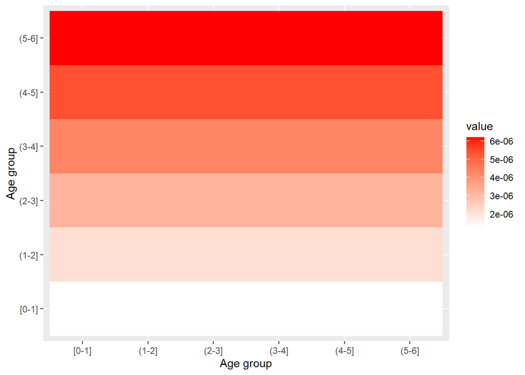

```r
plot_waifw(waifw6.fit1222$w4$bij)
```

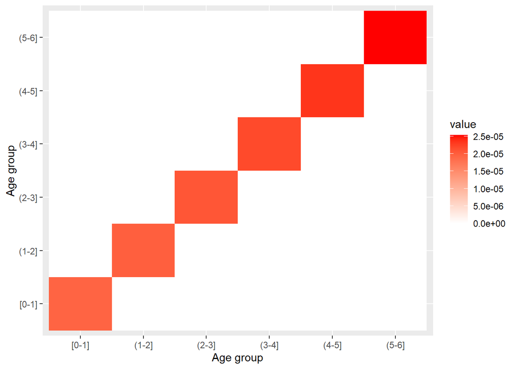

```r
plot_waifw(waifw6.fit1222$w6$bij)
```

## April 2023

**Fitting**

```r
waifw6.fit423 <- waifw.6parms(foihat=lp_fit423$foi[1:6],muhat=muhat,
                              breaks=breakpoints,
                              N=N,D=D,Lmax=6)
waifw6.fit423
```

```
$w1
$w1$message
[1] "D(lambda)lambda is irregular"

$w1$beta
[1] -4.852177e-04 -9.757789e-05 -3.937543e-05 -1.419123e-05 -2.085310e-07
[6]  8.454848e-06

$w1$R0hat
[1] NA

$w1$bij
[1] NA

$w1$L
[1] 5.952532

$w1$N
[1] 8068813

$w1$D
[1] 0.03835616


$w2
$w2$message
[1] "D(lambda)lambda is irregular"

$w2$beta
[1] -3.390684e-05 -1.900557e-05 -7.708874e-06 -1.137290e-07  4.983879e-06
[6]  8.454848e-06

$w2$R0hat
[1] NA

$w2$bij
[1] NA

$w2$L
[1] 5.952532
```

[output cut: 113 more lines]

```
[1,] 0.000000e+00
[2,] 0.000000e+00
[3,] 0.000000e+00
[4,] 0.000000e+00
[5,] 0.000000e+00
[6,] 2.549832e-05

$w6$L
[1] 5.952532

$w6$N
[1] 8068813

$w6$D
[1] 0.03835616
```

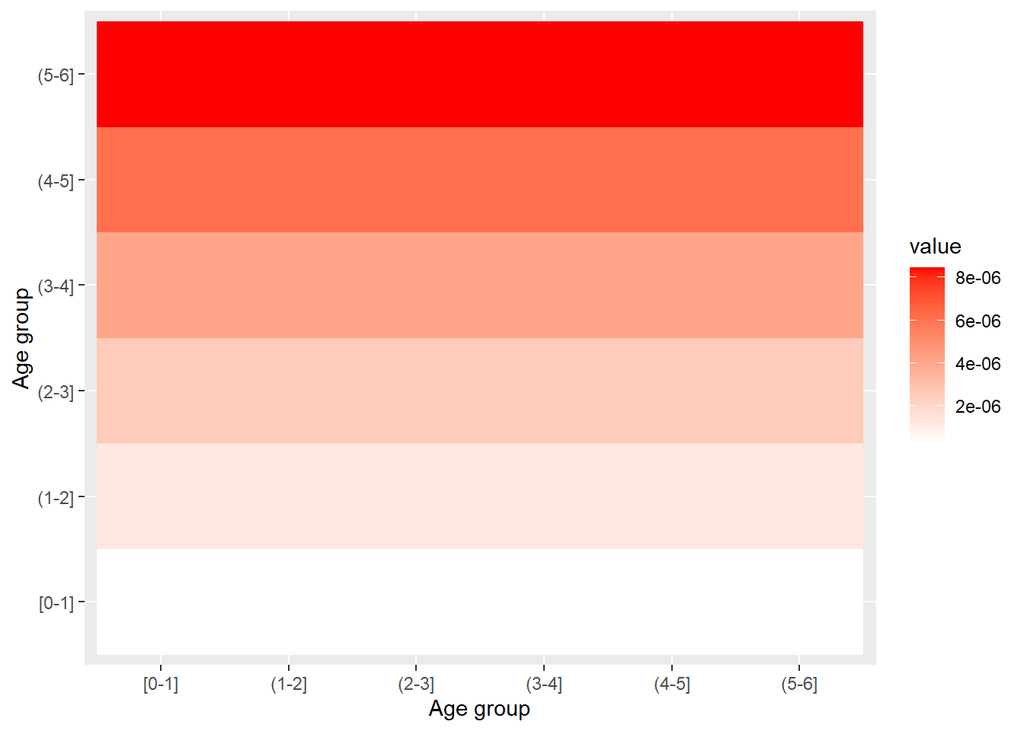

```r
plot_waifw(waifw6.fit423$w4$bij)
```

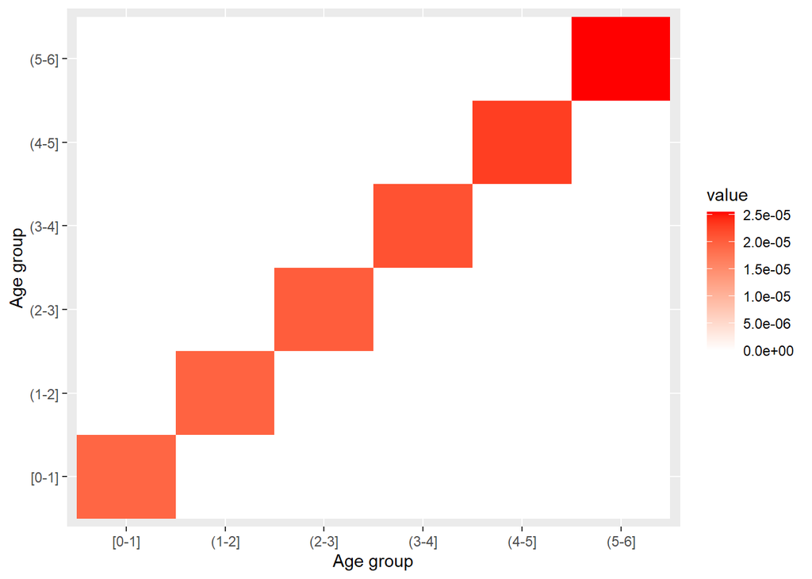

```r
plot_waifw(waifw6.fit423$w6$bij)
```

## August 2023

**Fitting**

```r
waifw6.fit823 <- waifw.6parms(foihat=lp_fit423$foi[1:6],muhat=muhat,
                              breaks=breakpoints,
                              N=N,D=D,Lmax=6)
waifw6.fit823
```

```
$w1
$w1$message
[1] "D(lambda)lambda is irregular"

$w1$beta
[1] -4.852177e-04 -9.757789e-05 -3.937543e-05 -1.419123e-05 -2.085310e-07
[6]  8.454848e-06

$w1$R0hat
[1] NA

$w1$bij
[1] NA

$w1$L
[1] 5.952532

$w1$N
[1] 8068813

$w1$D
[1] 0.03835616


$w2
$w2$message
[1] "D(lambda)lambda is irregular"

$w2$beta
[1] -3.390684e-05 -1.900557e-05 -7.708874e-06 -1.137290e-07  4.983879e-06
[6]  8.454848e-06

$w2$R0hat
[1] NA

$w2$bij
[1] NA

$w2$L
[1] 5.952532
```

[output cut: 113 more lines]

```
[1,] 0.000000e+00
[2,] 0.000000e+00
[3,] 0.000000e+00
[4,] 0.000000e+00
[5,] 0.000000e+00
[6,] 2.549832e-05

$w6$L
[1] 5.952532

$w6$N
[1] 8068813

$w6$D
[1] 0.03835616
```

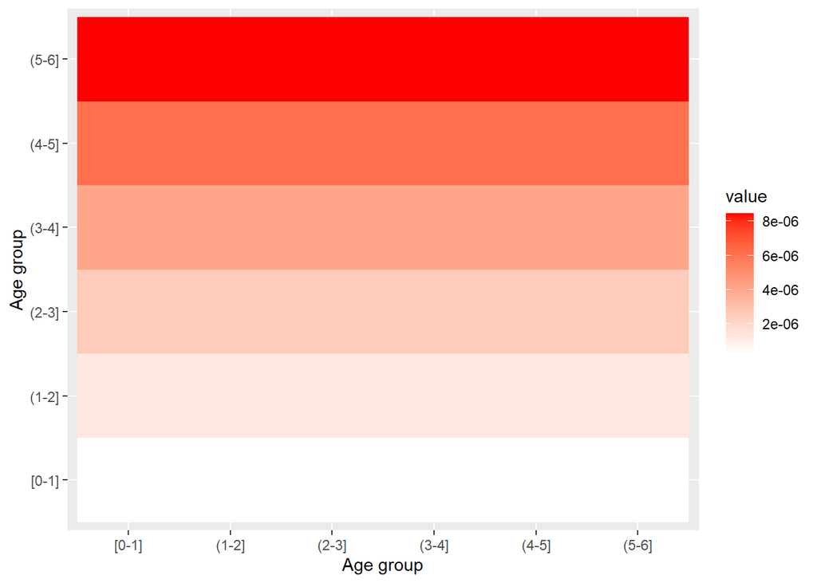

```r
plot_waifw(waifw6.fit823$w4$bij)
```

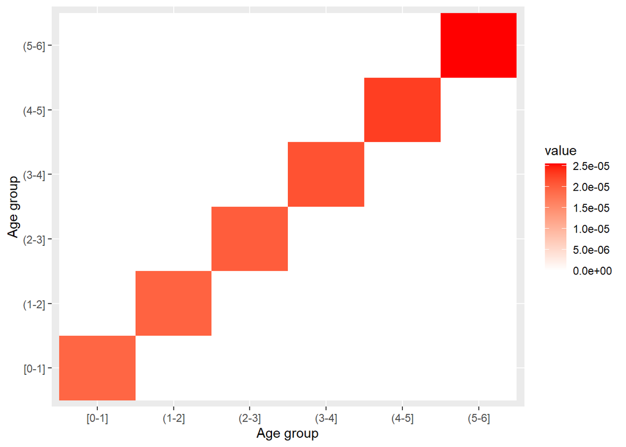

```r
plot_waifw(waifw6.fit823$w6$bij)
```

## December 2023

**Fitting**

```r
waifw6.fit1223 <- waifw.6parms(foihat=lp_fit1223$foi[1:6],muhat=muhat,
                              breaks=breakpoints,
                              N=N,D=D,Lmax=6)
waifw6.fit1223
```

```
$w1
$w1$message
[1] "D(lambda)lambda is irregular"

$w1$beta
[1] -6.183380e-05 -1.023538e-05  5.969066e-06  1.233458e-05  1.332819e-05
[6]  5.038202e-06

$w1$R0hat
[1] NA

$w1$bij
[1] NA

$w1$L
[1] 5.952532

$w1$N
[1] 8068813

$w1$D
[1] 0.03835616


$w2
$w2$message
[1] "D(lambda)lambda is irregular"

$w2$beta
[1] -1.736572e-05 -4.738644e-06  3.379147e-06  7.163212e-06  6.948924e-06
[6]  5.038202e-06

$w2$R0hat
[1] NA

$w2$bij
[1] NA

$w2$L
[1] 5.952532
```

[output cut: 113 more lines]

```
[1,] 0.000000e+00
[2,] 0.000000e+00
[3,] 0.000000e+00
[4,] 0.000000e+00
[5,] 0.000000e+00
[6,] 3.932358e-05

$w6$L
[1] 5.952532

$w6$N
[1] 8068813

$w6$D
[1] 0.03835616
```

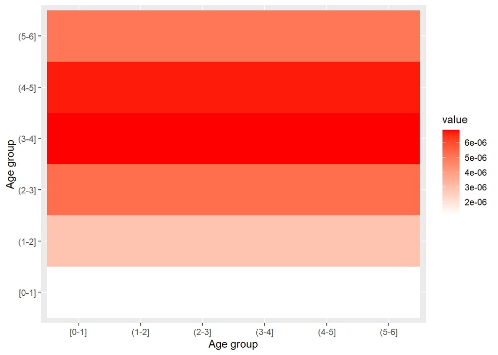

```r
plot_waifw(waifw6.fit1223$w4$bij)
```

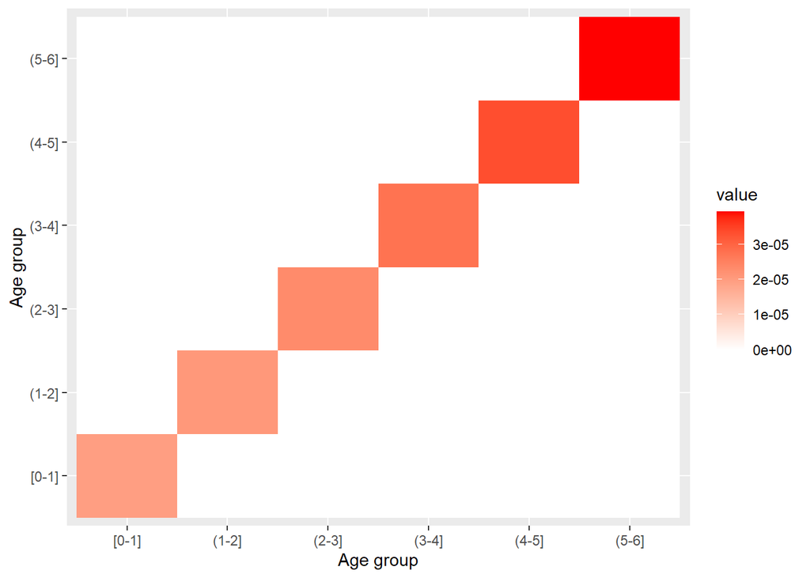

```r
plot_waifw(waifw6.fit1223$w6$bij)
```

W4 structure corresponds to the situation where transmissions rate depend only on the age of the susceptible, $\beta(a,a') = \beta(a)$ (Anderson and May 1991)

W6 structure corresponds to the transmissions process being primarily from contacts within age group

## References

Anderson, Roy M., and Robert M. May. 1991. *Infectious Diseases of Humans: Dynamics and Control*. OUP Oxford.

Hens, Niel, Ziv Shkedy, Marc Aerts, Christel Faes, Pierre Van Damme, and Philippe Beutels. 2012. “Nonparametric Approaches to Model the Prevalence and Force of Infection.” In, edited by Niel Hens, Ziv Shkedy, Marc Aerts, Christel Faes, Pierre Van Damme, and Philippe Beutels, 111–20. New York, NY: Springer. https://doi.org/10.1007/978-1-4614-4072-7_7.